# Intensive agriculture erodes β‐diversity at large scales - Karp - 2012 - Ecology Letters - Wiley Online Library

[Ecology Letters](https://onlinelibrary.wiley.com/journal/14610248)

[Volume 15, Issue 9](https://onlinelibrary.wiley.com/toc/14610248/2012/15/9)

Letter

Full Access

# Intensive agriculture erodes β‐diversity at large scales

[Daniel S. Karp](https://onlinelibrary.wiley.com/action/doSearch?ContribAuthorStored=Karp%2C+Daniel+S)

[Andrew J. Rominger](https://onlinelibrary.wiley.com/action/doSearch?ContribAuthorStored=Rominger%2C+Andrew+J)

[Jim Zook](https://onlinelibrary.wiley.com/action/doSearch?ContribAuthorStored=Zook%2C+Jim)

[Jai Ranganathan](https://onlinelibrary.wiley.com/action/doSearch?ContribAuthorStored=Ranganathan%2C+Jai)

[Paul R. Ehrlich](https://onlinelibrary.wiley.com/action/doSearch?ContribAuthorStored=Ehrlich%2C+Paul+R)

[Gretchen C. Daily](https://onlinelibrary.wiley.com/action/doSearch?ContribAuthorStored=Daily%2C+Gretchen+C)

First published: 21 June 2012

https://doi.org/10.1111/j.1461-0248.2012.01815.x

## Abstract

Biodiversity is declining from unprecedented land conversions that replace diverse, low‐intensity agriculture with vast expanses under homogeneous, intensive production. Despite documented losses of species richness, consequences for β‐diversity, changes in community composition between sites, are largely unknown, especially in the tropics. Using a 10‐year data set on Costa Rican birds, we find that low‐intensity agriculture sustained β‐diversity across large scales on a par with forest. In high‐intensity agriculture, low local (α) diversity inflated β‐diversity as a statistical artefact. Therefore, at small spatial scales, intensive agriculture appeared to retain β‐diversity. Unlike in forest or low‐intensity systems, however, high‐intensity agriculture also homogenised vegetation structure over large distances, thereby decoupling the fundamental ecological pattern of bird communities changing with geographical distance. This ~40% decline in species turnover indicates a significant decline in β‐diversity at large spatial scales. These findings point the way towards multi‐functional agricultural systems that maintain agricultural productivity while simultaneously conserving biodiversity.

## Introduction

The future of biodiversity hinges on the future of agriculture (Pereira *et al*. 2010) – protected areas alone will not sustain more than a small fraction of Earth's biota over the long run (Rosenzweig 2003). Although elements of native biodiversity persist today in many agricultural landscapes at local scales (Daily *et al*. 2001; Ranganathan *et al*. 2008; Fischer *et al*. 2010; Karp *et al*. 2011; Wright *et al*. 2012), current trends make it questionable whether or not this conservation value will persist.

Agricultural land planning now often occurs at large spatial scales, with extensive commercial operations replacing native habitats and smallholder farms. From 2004 to 2009, foreign land grabs for agriculture totaled close to 2.5 million hectares in just five African countries (Cotula *et al*. 2009), including a 452 500 ha biofuel project in Madagascar and a 150 000 ha livestock project in Ethiopia. In the Neotropics, agricultural expansion may eradicate 40% of the Amazon forest by 2050 (Soares‐Filho *et al*. 2006). In addition to clearing native habitat, large‐scale land acquisitions often make existing human‐dominated landscapes more uniform (Wright *et al*. 2012). In the tropics, many crop species were traditionally cultivated together and with patches of native vegetation. Now, large agricultural plots of few species are becoming increasingly common (Perfecto *et al*. 2009). Although this agricultural intensification is known to contribute to local diversity loss (Karp *et al*. 2011), its effect at larger spatial scales is less clear.

The most important determinant of diversity at large scales is the degree to which sites differ in their species compositions (β‐diversity) (Flohre *et al*. 2011). Despite rapid agricultural intensification in the tropics (Wright *et al*. 2012) and even though tropical β‐diversity is substantially higher than temperate β‐diversity (Buckley & Jetz 2008), very few studies have examined β‐diversity along tropical intensification gradients (Tylianakis *et al*. 2006; Kessler *et al*. 2009; Filloy *et al*. 2010). To our knowledge, only one of these studies tested the consequences of intensification for β‐diversity directly, finding no effect (Tylianakis *et al*. 2006). In temperate systems, on the other hand, there is building consensus that β‐diversity declines with agricultural intensification, although the effect is not universally found (Gabriel *et al*. 2006; Clough *et al*. 2007; Hendrickx *et al*. 2007; Vellend *et al*. 2007; Ekroos *et al*. 2010; Flohre *et al*. 2011).

One possible explanation for divergent observations is that the intensification effects are scale‐dependent – β‐diversity declines most when evaluated at larger scales. Within farms or between nearby farms, increasing intensification may not affect β‐diversity (Tylianakis *et al*. 2006). In contrast, there is evidence that intensification causes declines in β‐diversity at larger scales, between regions for example (Gabriel *et al*. 2006; Flohre *et al*. 2011). Understanding scale‐dependent relationships between intensification and β‐diversity necessitates resolving mechanisms behind β‐diversity declines. However, research that explicitly evaluates the idea that the relative impact of intensification on β‐diversity is highest at large spatial scales does not currently exist, let alone research that attempts to identify mechanisms underlying scale‐dependent relationships.

β‐diversity is thought to accumulate at large spatial scales as a result of dispersal limitation, co‐variation with environmental conditions, and community assembly history (Whittaker 1960; Condit *et al*. 2002; Rominger *et al*. 2009; Fukami 2004; Martiny *et al*. 2011). Because intensive land‐use practices may select for species with high dispersal abilities, continued agricultural intensification may allow a characteristic suite of good dispersers to spread over large distances, lowering β‐diversity (Vellend *et al*. 2007; Ekroos *et al*. 2010). In addition, β‐diversity may decline in response to physical alterations of the environment. Many species are restricted to specific environmental conditions, and the natural turnover of communities with geographical distance is thought to in part result from co‐varying changes in environmental conditions (Whittaker 1960; Rominger *et al*. 2009; Martiny *et al*. 2011).

Human activities often reproduce similar physical environments over large distances, disrupting environmental gradients (McKinney 2006). Agricultural intensification in particular can lower biodiversity by homogenising landscape mosaics into simplified, expansive crop fields (Tscharntke *et al*. 2005). Only species with a distinct set of physical, life‐history, and functional traits survive in high‐intensity agriculture; for example, dietary generalists persist, while specialists in diet and habitat do not (Lindell *et al*. 2004; Tscharntke *et al*. 2008). Therefore, as intensive agriculture replaces distant sites that previously supported distinct vegetation types or environmental conditions, a characteristic set of agriculture‐associated species may replace previously unique biological communities. In this case, effects of intensification on β‐diversity would be strongest across previously distinct regions or biomes that were altered to subsequently exhibit similar environmental conditions. In practice, however, evidence that changing environmental structure causes β‐diversity declines in intensified landscapes is conflicting (Tylianakis *et al*. 2006; Hendrickx *et al*. 2007; Vellend *et al*. 2007; Filloy *et al*. 2010).

Here, we analyse the consequences of land‐use intensification for tropical bird β‐diversity across spatial scales. Unlike most previous analyses of β‐diversity that have relied on one season of field surveys, we use one of the most comprehensive data sets available for any tropical vertebrate taxon. The data set consists of 2 640 censuses, conducted at 44 transects and surveyed by the same expert observer (J. Zook) from 2000 to 2009. The transects are located across Costa Rica, and represent a range of environmental conditions and habitat types. Critically, we contrast bird communities located in low‐intensity agriculture (*n* = 16), high‐intensity agriculture (*n* = 16), as well as intact forest (*n* = 12). Previous studies of the impacts of agricultural intensification on β‐diversity generally have not included natural habitats as study sites. If low‐intensity agriculture maintains β‐diversity at levels similar to natural habitat, then reducing the intensity of production may result in large conservation gains. Alternatively, if β‐diversity is always substantially higher in natural habitat, then managing agricultural intensification for conservation may not be effective.

We first analyse the effect of land‐use intensification on bird β‐diversity at multiple spatial scales, focusing on bird communities (1) within the same ecoregion, (2) different ecoregions, and (3) different biomes. Next, we uncover mechanisms for scale‐dependent effects of land‐use intensification on bird β‐diversity, examining rates of bird community turnover and vegetation structure turnover with geographical distance in each land‐use treatment. We then develop a simulation‐based null model to show how local (α) diversity may also mediate differences in β‐diversity among land‐use treatments. Finally, by comparing community‐level functional diversity among land‐use treatments, we test the idea that only species with a distinct set of traits are able to occupy high‐intensity agriculture.

## Methods

### Study sites and bird censuses

In 1999, we arrayed transects in four study circles across Costa Rica, each study circle with a unique set of land uses: Puerto Viejo (heart‐of‐palm, banana and cattle); San Isidro (coffee, pineapple, sugar cane and cattle); Las Cruces (coffee and cattle); and Guanacaste (melon, rice, sugar cane, cattle and aquaculture) (Fig. S1). Study circles were separated by 190 km on average, and the closest two circles (Las Cruces and San Isidro) were 92 km apart. The study circles were also located in noticeably distinct eco‐regions: Las Cruces and San Isidro were both classified as Isthmian‐Pacific moist forest ecoregions; Puerto Viejo was Isthmian‐Atlantic moist forest ecoregion; and Guanacaste was Central American dry forest ecoregion (Olson *et al*. 2001). As dry forest, the Guanacaste study circle was also a distinct biome from the other study circles.

In each study circle, we placed twelve 200‐metre transects along a gradient of land‐use intensification—from intact forest preserves to intensified monocultures. Transects in the same study circle were separated 10 km on average, with a maximum distance of 30 km. To assign transects to land‐use intensity treatments, we characterised the vegetation at each transect in 1999 and 2002, and obtained a land‐use classification map through Fondo Nacional de Financiamiento Forestal (FONAFIFO). Because intensification affects biodiversity both onsite and at the landscape‐level (Tscharntke *et al*. 2005), we calculated the pairwise dissimilarity in vegetation structure (Gower Dissimilarity) between all non‐forest transects based on local‐level variables (number of planted crop species, hedgerow quality and size, agriculture plot size, number of vegetation strata) and landscape‐level variables (per cent forest cover at 100 and 200 m radii) (Table S1). We then used dissimilarity values for cluster analysis (unweighted average pair‐group mean), and separated non‐forest transects into two intensity treatments: ‘low intensity’ (*n* = 17) and ‘high intensity’ (*n* = 19) (Fig. S2).

Compared to high‐intensity agriculture, low‐intensity agriculture had fewer and smaller agricultural plots with higher surrounding forest cover, larger and fuller hedgerows for birds (Hughes *et al*. 2002), more planted crop species and more vegetation strata (Table S1). On average, farm plots in high‐intensity agriculture were ~20 times larger with ~5 times fewer crop species than farm plots in low‐intensity agriculture (Table S1). After repeating clustering with data from 2002, only two transects changed in classification. After 2002, two more transects underwent significant modification. Therefore, we excluded these four transects, and restricted analyses to 12 transects in forest, 16 transects in low‐intensity agriculture and 16 transects in high‐intensity agriculture (*n* = 44 transects in total).

From 2000 to 2009, these transects were sampled two seasons per year with three visits per season by the same expert observer (J. Zook). Because censuses took place in the dry and wet seasons, both migratory and breeding birds were included in our censuses. The order for transect surveys was varied each day so that transects were surveyed at similar times. Surveying began at sunrise, and each survey lasted 30 min. All birds within 50 m of the transect line were recorded, except flythrough birds and flyovers. To minimise counting temporary immigrants, our analyses excluded nomadic species and species in migratory flux during sampling periods, but our results were robust to including these species: some trends became non‐significant but no trends changed in direction (Fig. S3a,b,c; Fig. S4a,c).

### β‐diversity and turnover rates

The impact of land‐use intensification on bird β‐diversity was examined after calculating pairwise dissimilarity in species composition between all combinations of transect pairs. Although multiple measures of β‐diversity have been proposed (Anderson *et al*. 2011a), we chose pairwise dissimilarity due to the statistical power gains that allow for analyses at multiple spatial scales. To calculate pairwise dissimilarity, we used an estimator that accounts for unseen species and incorporates species abundances (Chao *et al*. 2005). Although several trends were no longer significant, trends did not change in direction with an incidence‐based measure (Chao *et al*. 2005) (Fig. S3d,e,f; Fig. S4b,d).

We examined the impact of intensification on β‐diversity at three spatial scales by computing the average dissimilarity in bird community composition between transects located in (1) the same eco‐region, (2) different eco‐regions and (3) different biomes (Fig. 1a). For analyses within eco‐regions, the Las Cruces and San Isidro study circles were lumped together, and dissimilarities were restricted to transect pairs that were both located in Las Cruces/San Isidro, Puerto Viejo, or Guanacaste. For analyses between ecoregions, dissimilarities were calculated between pairs of transects in which one transect was located in Las Cruces/San Isidro, Puerto Viejo, or Guanacaste and the other was located in a different ecoregion. Finally, for analyses between biomes, the Las Cruces, San Isidro and Puerto Viejo study circles were lumped together, and dissimilarities were calculated between a transect in one of these study circles and another in Guanacaste.

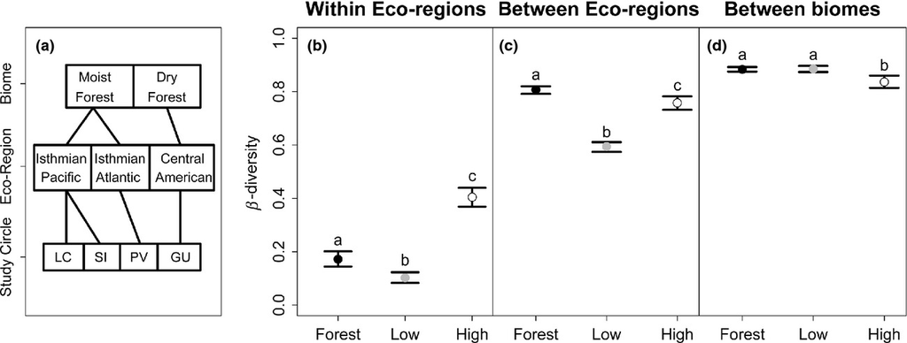

**Figure 1**

Effect of land‐use intensification on β‐diversity. Panel a: β‐diversity analyses were conducted at three scales: within eco‐regions, between eco‐regions, and between biomes. The study circles (Las Cruces‐ LC; San Isidro‐ SI; Puerto Viejo‐ PV; Guanacaste‐ GU) were classified into three eco‐regions and two biomes. Panel b: Within eco‐regions, high‐intensity agriculture had higher β‐diversity (mean dissimilarity) than forest or low‐intensity agriculture. Plots show the mean value (points) from 2000 bootstrapped replicates of mean dissimilarity for each land‐use treatment (forest = black, low‐intensity = grey, high‐intensity = white). Whiskers are 95% confidence intervals for bootstrapped replicates. Panel c: β‐diversity of forest communities increased between eco‐regions, overtaking communities in high‐intensity agriculture. Panel d: Between biomes, β‐diversity in forest and low‐intensity agriculture was higher than in high‐intensity agriculture. Letters denote significance.

To assess effects of land‐use intensification on species turnover rates, we regressed bird community dissimilarity between transect pairs against the geographical distance between the two transects, using ordinary least squares. We report the slope of the regression line (turnover rate) and fit of the regression line (*R*<sup>2</sup>). All combinations of transect pairs were used. We also used these regressions to generate an alternate measure of β‐diversity by constraining the slopes of regression lines relating community dissimilarity to geographical distance, allowing the intercepts to vary. These intercepts served as a measure of average dissimilarity that accounted for differing degrees of spatial autocorrelation among the three land‐use intensity treatments. No trends changed in direction or became non‐significant when using intercepts as measures of β‐diversity (Fig. S3g,h,i); therefore, we report β‐diversity as average dissimilarity among transect pairs.

Utilising all pairwise comparisons of transects violates independence assumptions in linear regression. Therefore, for all analyses of β‐diversity and turnover rates, we generated bootstrapped estimates of mean dissimilarity, regression slopes and *R*<sup>2</sup> values (*n* = 2000 bootstrapped replicates), randomising draws by seasonal blocks to preserve the dependence structure in the data. Thus, if data deviate from bootstrap replicates, it is not attributable to dependence. We then examined the 95% confidence intervals around bootstrapped mean dissimilarities, regression intercepts, slopes and *R*<sup>2</sup> values to compare β‐diversity and turnover rates between land‐use intensity treatments.

### β‐diversity drivers

We examined the driver of species turnover rates by relating community similarity and geographical distance to similarity in vegetation structure. We first computed pairwise dissimilarity in vegetation structure from a land‐use map (FONAFIFO) and vegetation surveys conducted in 2000 and 2002 at transects in low‐intensity and high‐intensity agriculture. We used a Gower dissimilarity measure, based on the same vegetation variables used to define the land‐use treatments. We then used two separate Mantel tests to correlate similarity in vegetation structure to geographical distance and bird community dissimilarity for low‐intensity and high‐intensity agriculture.

The expected relative abundance of each species computed from the log‐series distribution was used as the probability of drawing that species when simulating the accumulation of species in each transect. Individuals were apportioned to species using a multinomial distribution; probabilities were taken to be the relative abundances of the species in the meta‐community. The simulations were run for 2000 iterations. For each iteration, we calculated Chao's quantitative dissimilarity for each within eco‐region pairwise comparison and recorded the mean dissimilarity across transects.

We used these mean dissimilarities as a null distribution to address whether α‐diversity and stochastic sampling of the meta‐community drive observed patterns of within ecoregion β‐diversity. To do so, we calculated z‐scores for β‐diversity in each of the land‐use types. The z‐score is defined as (β<sub>obs</sub> − mean(β<sub>sim</sub>))/SD(β<sub>sim</sub>), where β<sub>obs</sub> and β<sub>sim</sub> are the observed and simulated β‐diversities respectively. The z‐score represents the β‐diversity not accounted for by stochastic sampling of the meta‐community. We compared the distributions of bootstrapped z‐scores between land‐use treatments, evaluating how patterns across land‐use treatments changed in comparison to the previous analysis that did not correct for stochastic sampling.

As another check that α‐diversity can drive patterns in β‐diversity, we repeated analyses of β‐diversity at all spatial scales using Raup–Crick dissimilarity and compared them to analyses using Chao dissimilarity (Raup & Crick 1979). Raup–Crick dissimilarity is an incidence‐based, probabilistic metric that is not influenced by α‐diversity (Vellend *et al*. 2007).

Finally, we evaluated the hypothesis that high‐intensity agriculture functions as an ecological filter. We computed the observed functional diversity (Petchey & Gaston 2002) of bird communities in forest, low‐intensity, and high‐intensity agriculture, compiling information on bird resource and acquisition traits (Stiles & Skutch 1989; Flynn *et al*. 2009): size (mass, length), sociality (solitary, pairs, monospecific groups, heterospecific groups), foraging strata (water, ground, lower, middle, upper, canopy, above canopy), and foraging behaviour (aerial, sallying, foliage gleaning, bark gleaning, ground rummaging, berry plucking, stalking). We then compared observed functional diversity in forest, low‐intensity, and high‐intensity agriculture to the functional diversity of 1000 randomised bird communities of the same species richnesses (forest: *n* = 283; low‐intensity: *n* = 265; high‐intensity: *n* = 230). We assessed whether or not trends were robust to the traits considered by sequentially excluding traits, recalculating functional diversity, and repeating randomisation analyses (jackknifing).

## Results

We found that the relative impact of agricultural intensification depended on spatial scale (Figs. 1b–d). Within eco‐regions, bird communities in high‐intensity agriculture had significantly higher β‐diversity than communities in forest or low‐intensity agriculture (95% confidence intervals of bootstrapped replicates were non‐overlapping; Fig. 1b). For transects located in different eco‐regions, bird communities in forest overtook high‐intensity agriculture in β‐diversity (Fig. 1c). When transects in different biomes were compared, in addition to the forest communities, the β‐diversity of communities in low‐intensity agriculture also surpassed β‐diversity in high‐intensity agriculture (Fig. 1d).

The increasing effect of intensification on β‐diversity with spatial scale was likely due to altered rates of turnover in community composition with geographic distance. For all treatments, dissimilarity in bird community composition increased with distance between sites (Fig. 2a); however, turnover rates were 42 and 38% lower in high‐intensity agriculture than in forest and low‐intensity agriculture respectively (Fig. 2b). Moreover, the variance in community composition explained by geographical distance declined with intensification (Fig. 2c). Therefore, as spatial scale increased, β‐diversity accumulated faster in forest and low‐intensity agriculture than in high‐intensity agriculture.

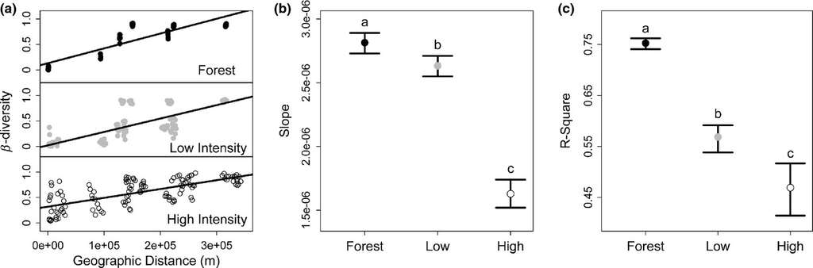

**Figure 2**

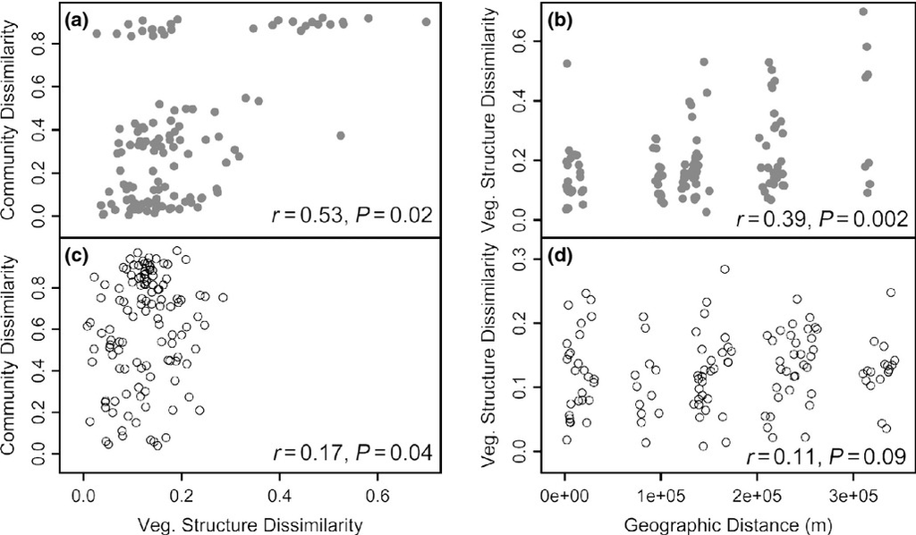

**Figure 3**

Relationships between dissimilarity in bird community composition (Chao dissimilarity), dissimilarity in vegetation structure (Gower dissimilarity), and geographic distance (metres). Intensive production practices resulted in uniform environmental conditions, disrupting natural patterns in avian turnover with distance. As differences in vegetation structure accumulated, bird community composition became more dissimilar in low (Panel a) and high‐intensity (Panel c) transects. Differences in vegetation structure accumulated with geographic distance in low‐intensity agriculture (Panel b); however, vegetation structure was highly similar among transects in high‐intensity agriculture and did not change with distance (Panel d). Each point represents a pair of transects.

Altered turnover rates explain why the effect of intensification on β‐diversity increased with spatial scale. It is not intuitive, however, why bird communities in high‐intensity agriculture should ever have higher β‐diversity than bird communities in forest or low‐intensity agriculture. One explanation is that because overall bird biomass declines in high‐intensity agriculture (Kruskal–Wallis: χ<sup>2</sup>= 7.89; d.f. = 2.41; *P* = 0.019; Fig. S5a), fewer species can occupy any given location. We hypothesised that if many species have the potential to occupy high‐intensity agriculture, but the number of species occupying any given site is constrained, then sites may exhibit more differences in their species compositions as a sampling effect. In other words, a sampling effect may arise as a product of randomly drawing only a few species from a larger species pool that has the ability to occupy high‐intensity agriculture.

At our study sites, local, transect‐scale diversity in high‐intensity agriculture declined by 45 and 36% relative to forest and low‐intensity agriculture respectively (*F* = 14.0; d.f. = 2.41; *P* < 0.001). This decline was not attributed to incomplete censusing: species accumulation curves at each transect appeared saturated, and high‐intensity agriculture had significantly lower species richness when both raw and estimated species richness were used (Fig. S5b,c). Our simulation experiment tested the idea that low species richness in high‐intensity sites may drive patterns in β‐diversity. After accounting for differing species richnesses among land‐use treatments, we found that high‐intensity agriculture no longer had higher β‐diversity than forest (Fig. 4). Instead, forest had higher β‐diversity than both low‐intensity and high‐intensity agriculture (Fig. 4). Furthermore, when analyses were repeated with Raup–Crick dissimilarity, a metric independent of α‐diversity, high‐intensity agriculture was no longer more β‐diverse than forest or low‐intensity agriculture within ecoregions (Fig. S3j). However, the relative impact of intensification on β‐diversity still increased with spatial scale (Fig. S3j,k,l). Therefore, within ecoregions, relatively high β‐diversity in high‐intensity agriculture was probably an artefact of low α‐diversity.

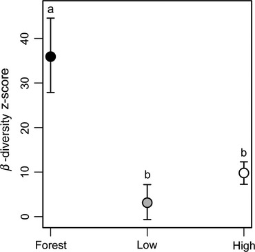

**Figure 4**

Effect of land‐use intensification on β‐diversity, accounting for α‐diversity. Points indicate mean z‐score; whiskers are 95% confidence intervals from 2000 bootstrap replicates. Z‐scores represent the standardised difference between observed β‐diversity and that expected under null simulations in which species are drawn at random from meta‐communities. Simulations matched observed data in abundance, α‐diversity, and meta‐community structure. After accounting for α‐diversity, forest sites (black points) have significantly higher β‐diversity (z‐score dissimilarity) within eco‐regions than low‐intensity (grey) and high‐intensity (white) agriculture. Letters denote significance.

We also found that bird community functional diversity was significantly (~40%) lower in high‐intensity agriculture than that in forest or low‐intensity agriculture (*F* = 15.8, d.f. = 2.41, *P <* 0.001). After controlling for differences in species richness among the land‐use treatments, we found that high‐intensity communities exhibited significantly lower functional diversity compared to randomly generated communities, while forest and low‐intensity communities demonstrated comparable functional diversity relative to bootstrapped replicates (Fig. 5). This result was generally robust to the traits considered; however, foraging stratum was particularly important in driving functional diversity in forest communities.

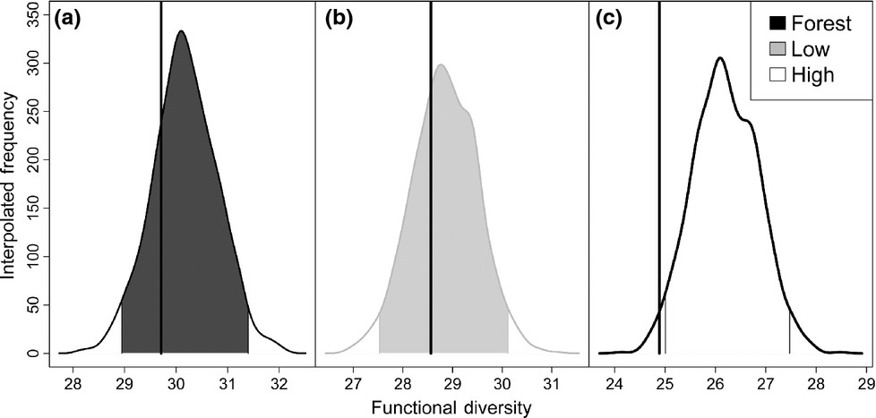

**Figure 5**

Functional diversity of bird communities by land‐use treatment (Panel a: forest, Panel b: low‐intensity agriculture, Panel c: high‐intensity agriculture). Vertical black lines are observed functional diversity, and distributions are estimated probability density derived from random bootstrapped communities (*n* = 1000) of the same species richnesses as observed communities. Shaded regions indicate 95% of the bootstrapped replicates. The bird assemblage occupying high‐intensity agriculture had significantly lower functional diversity than random communities; therefore, a limited subset of species persisted in intensively managed landscapes.

## Discussion

To our knowledge, our results documented, for the first time, declines in tropical β‐diversity as a result of land‐use intensification. We found that high‐intensity agricultural practices limited the number of species that occupied any given location. Limiting local diversity caused β‐diversity to increase at small spatial scales; therefore, apparent β‐diversity of transects located in the same ecoregion was highest in high‐intensity agriculture. When a different β‐diversity metric was used (a metric independent of α‐diversity), we observed no effect of land‐use intensification within ecoregions. Previous studies of land‐use intensification in the tropics were conducted at small spatial scales; therefore, it is unsurprising that β‐diversity declines as a result of agricultural intensification were not documented (Tylianakis *et al*. 2006; Kessler *et al*. 2009).

High‐intensity agricultural practices, however, also caused similar vegetation structure across large distances, while low‐intensity agricultural practices maintained a natural turnover of vegetation structure with distance. Because bird communities tracked changes in vegetation structure, bird community turnover rates were significantly lower in high‐intensity agriculture than in forest or low‐intensity agriculture. Whether or not agricultural intensification causes declines in β‐diversity by homogenising environmental conditions is contested (Hendrickx *et al*. 2007; Vellend *et al*. 2007; Ekroos *et al*. 2010). Our results support the idea that land‐use intensification increases similarity in environmental conditions between distant sites, reducing β‐diversity. Therefore, as spatial scale increased, we observed that β‐diversity in high‐intensity agriculture decreased relative to low‐intensity agriculture and forest. This pattern of an increasing effect of land‐use intensification on β‐diversity with spatial scale, although previously undocumented explicitly, is in line with previous findings in temperate systems (Gabriel *et al*. 2006; Flohre *et al*. 2011). In summary, within ecoregions, where vegetation structure was similar for all land‐use treatments, sampling effects caused β‐diversity to be highest in high‐intensity agriculture. Between ecoregions and biomes, homogenised vegetation structure overpowered sampling effects, causing a significant decline in bird β‐diversity relative to forest or low‐intensity agriculture.

We also documented that high‐intensity agriculture acts as an ecological filter, limiting the functional diversity of bird communities. In general, lowering species richness reduces functional diversity. Like other studies (Flynn *et al*. 2009), however, we observed lower functional diversity in high‐intensity agriculture beyond what would be expected given the number of species in the species pool. This is in contrast to bird communities in forest and low‐intensity agriculture, which exhibited expected levels of functional diversity. Low functional diversity in high‐intensity agriculture likely reflects the fact that only a subset of traits allow for persistence in intensive agricultural conditions (Lindell *et al*. 2004; Tscharntke *et al*. 2008; Ekroos *et al*. 2010).

Our results suggest that rapid rates of agricultural expansion and intensification threaten diversity not only locally, but also at larger spatial scales. Community dissimilarity was strongly related to distance in forest and low‐intensity agriculture; therefore, as agriculture expands, low‐intensity agricultural practices across regions will be essential to maintain regional diversity. Otherwise, biotic homogenisation at large scales may accelerate species loss beyond even current dire predictions (Pereira *et al*. 2010; Barnosky *et al*. 2011).

The consequences for humanity may be far‐reaching: diversity is related to both the provision of services by Earth's life‐support systems and their resilience (Olden *et al*. 2004; Balvanera *et al*. 2006). Bird diversity has been linked to pollination (Anderson *et al*. 2011b), fruit dispersal (Breitbach *et al*. 2010) and pest‐control services (Van Bael *et al*. 2008). Functional diversity, in particular, has been shown to drive many ecosystem processes (Tilman 1997). The low functional diversity that we observed in high‐intensity transects may thus make intensification particularly detrimental to bird‐mediated processes and services. Moreover, ecosystem‐service resilience requires service providers to respond differently to disturbances (Olden *et al*. 2004; Kremen 2005). By acting as an ecological filter, intensive land‐use practices may eliminate important service providers in the process of homogenising biological communities, thereby limiting response diversity and resilience against future natural and anthropogenic disturbances (Olden *et al*. 2004).

Encouragingly, however, our results yielded the novel insight that diversity at large spatial scales, as well as underlying ecological patterns, is remarkably similar in forest and land subjected to low‐intensity agricultural practices, still typical across much of the tropics (Perfecto *et al*. 2009). Multiple taxa have already been shown to persist in low‐intensity agriculture across the world (Daily *et al*. 2003; Ranganathan *et al*. 2008; Karp *et al*. 2011). Furthermore, biodiversity may be locally sustained on farmland through small scale land‐use decisions, such as maintaining nearby forest elements or using trees as ‘live fences’ (Hughes *et al*. 2002; Mendenhall *et al*. 2011). As mentioned, previous analyses of β‐diversity in farmland have not included natural habitats. That low‐intensity agricultural practices maintain β‐diversity at levels similar to forest means local land‐use decisions made by individual landowners can sustain biodiversity not only on their own private lands but also at large spatial scales.

To feed the expanding human population, food production will have to increase greatly by 2050 (Tilman *et al*. 2001; Foley *et al*. 2011). This will precipitate future agricultural expansion and intensification. Already, large‐scale land transformations are becoming increasingly common (Soares‐Filho *et al*. 2006; Cotula *et al*. 2009). Here, we demonstrate that large‐scale agricultural intensification disrupts ecological patterns critical for maintaining biological diversity. Lowering the intensity of agricultural production in some dimensions, by planting diversified farms and retaining remnant tree patches, holds great promise for sustaining vital biodiversity and ecosystem‐service values while increasing food production.

## Acknowledgements

We thank H. Mooney, T. Fukami and three anonymous referees for comments and reviews. We are indebted to private landowners, as well as the Organization for Tropical Studies and Los Cusingos Bird Sanctuary for years of research on their properties. We are grateful for financial support through a National Science Foundation graduate research fellowship to DS Karp and AJ Rominger and from the Moore Family Foundation, the Winslow Foundation and Peter and Helen Bing.

## Authorship

DSK, PRE and GCD designed research; JZ collected data; JR compiled data; DSK and AJR analysed data; DSK, AJR, PRE and GCD wrote the paper.

## Citing Literature

[Volume15, Issue9](https://onlinelibrary.wiley.com/toc/14610248/2012/15/9)

September 2012

Pages 963-970

### Details

  © 2012 Blackwell Publishing Ltd/CNRS

### Keywords

  - Agriculture
  - bird
  - [countryside biogeography](https://onlinelibrary.wiley.com/action/doSearch?field1=Keyword&text1=countryside%20biogeography)
  - [environmental filtering](https://onlinelibrary.wiley.com/action/doSearch?field1=Keyword&text1=environmental%20filtering)
  - homogenisation
  - intensification
  - [sampling effects](https://onlinelibrary.wiley.com/action/doSearch?field1=Keyword&text1=sampling%20effects)
  - turnover
  - [β‐diversity](https://onlinelibrary.wiley.com/action/doSearch?field1=Keyword&text1=%CE%B2%E2%80%90diversity)